# Afraid of flight cancellation?

## Analysis of Pre-Covid US flights

## by Kacper Fiszer

## Background

During Covid pandemic everything got crazy, very much including air travel.  
Even before, **flight delays and cancellations were painful**.

Although delays are annoying and can alter your schedule,  
**what's worse than a flight diverted or cancelled altogether?**

## Investigation Overview

- The analysis is focused on **cancelled and diverted flights**.  
  Are they more likely in certain conditions?
- We will also briefly look at **high-level flight delay relations**.

## Dataset Overview

- The dataset contains complete US flight data in the years **2005-2007**.  
  Over 21 Million records, flight by flight.
- Plots were generated on a sample for visual clarity.

# Part I: Delays

## Are they related to any high-level factors?

## Relation between distance and arrival delay

- It would probably make sense to think that the longer the flight is, the longer the typical delay on arrival.
- Except it is not so. Long flights tend to have **very similar lengths of arrival delays** (or landing ahead of schedule) as shorter flights.
- Could that be because they have more time in the air to catch on in case of departure delay?  
  That's a question for another story.

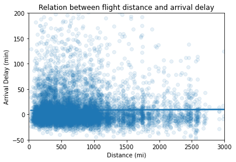

## Relation between departure delay and arrival delay

- If the flight is already **delayed on departure**, it would surely be **delayed upon arrival** as well, right?
- This tends to be **true**, yes - especially **for longer delays**.
- However, with delays in the region of **0 +- 30 minutes** everything can happen.  
  That is, **flights ahead of schedule on departure can arrive late or vice versa**.
- **Warning:** contains product placement.

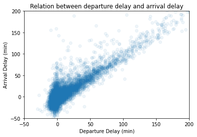

## Relation between scheduled flight time and actual elapsed time

- Is it linear? Do flights generally take **as much time as the schedule says**?
- Actually, yes. The industry seems quite reliable, or at least it was before the pandemic.
- The second visual adds distance category to the plot.  
  Much of a surprise: **longer distances take more time to fly** .  
  But as long as the plot resembles tequila sunrise, I'm fine with that.

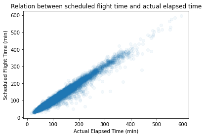

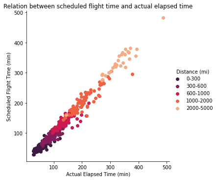

- As much as the general relation is linear, there is more to it.
- When we break the plot down by distance categories, it appears that for shorter distances the points lie farther apart.
- That is, **for shorter distances the scheduled duration is more likely to differ from the actual duration**.

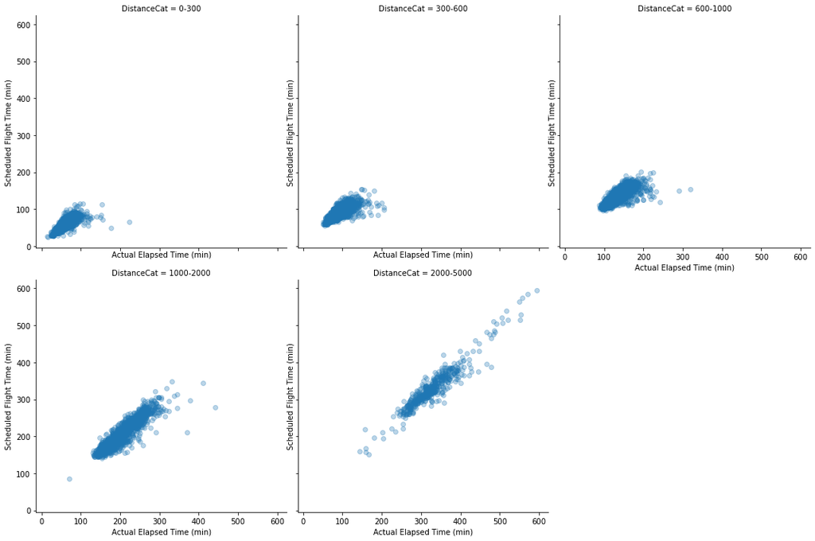

# Part II: Cancelled and Diverted flights

## Should we fear them?

#### (At least when we are back to normal)

## Count and proportion of cancelled or diverted flights by year

- Are there **noticeable fluctuations** year-to-year?
- As you can see in the plot, year **2007 had visibly more cancellations and diverted flights than 2005 or 2006** .
- Still, wouldn't even try to compare that to 2020 or 2021, for the sake of emotional well-being.

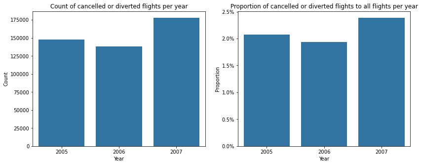

## Count and proportion of cancelled or diverted flights by month

- Are there **noticeable fluctuations** by each month?
- As you can see, **counts distribution is very similar to proportions**.
- In short, **winter is the season with highest cancelled or diverted flights** numbers.
- **Summer is the second worst** - maybe hot weather is not much better for planes and infrastructure than winter?  
  That would require further analysis.

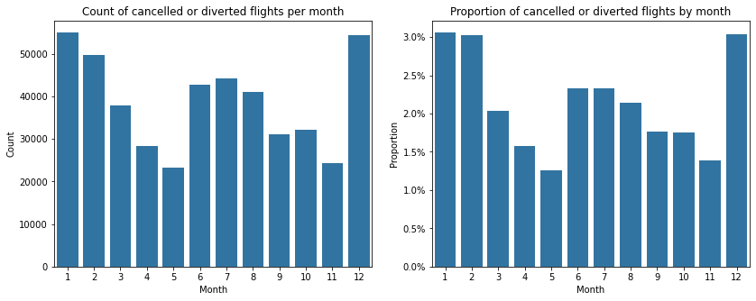

## Count and proportion of cancelled or diverted flights by day of week

- For the third time proportion behaves mostly similarly to distribution of counts.
- The proportion of cancelled or diverted flights on weekends is a bit higher than raw counts would suggest.
- **Weekends and Saturdays in particular were the 'safest' days to avoid a flight being cancelled or diverted**.

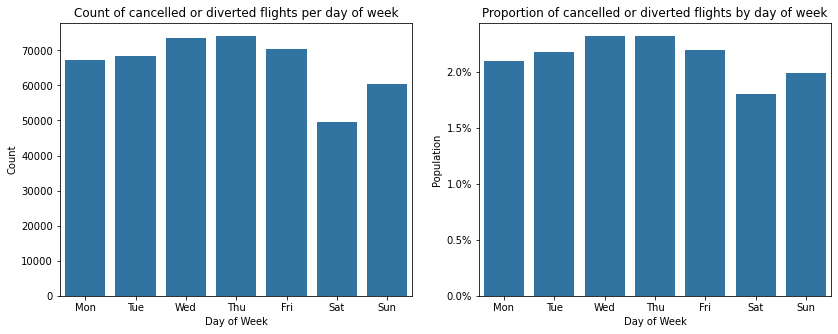

## Cancelled or diverted flights by month and day of week

- **Month and day of week seem to have more influence** over cancellations and diverting flights than a year has (sidenote: unless it's 2020 or 2021).
- There is a **higher chance of a flight getting cancelled or diverted on December Fridays**. Christmas peak + bad weather?
- Conversely, the **least cancelled/diverted flights occured on May and November Saturdays**.

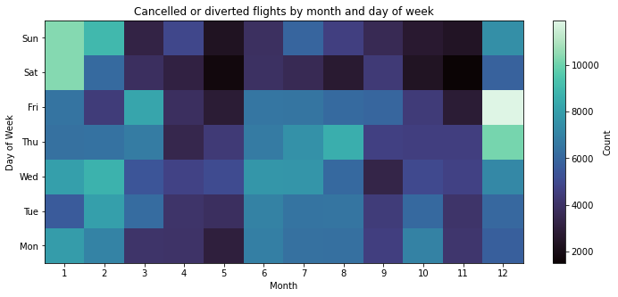

## Count of cancelled or diverted flights by distance

- On a logarithmic scale, the distribution of flight distances appears more normal, with a few peaks.
- Possibly popular big city destinations generating lots of traffic between themselves?
- In any case, **whether or not a flight ends up cancelled or diverted doesn't correlate with flight distance**.

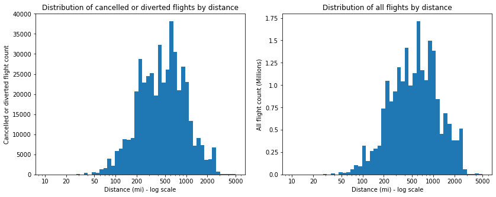

## Proportion of flight cancellation reasons

- The **most frequent** reason of flight cancellation are **Carrier issues**.
- **Second** most frequent is the **Weather**.
- Flights are **almost never cancelled due to Security** reasons.

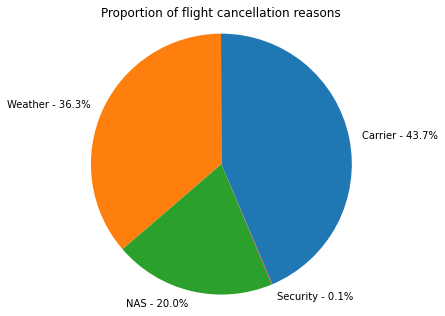

## Cancellation reasons in relation to flight distance

- For as few as there are (look at the previous pie chart), **Security**-related flight cancellations happen for **shorter flights** than with other reasons.
- **Weather**-related cancellations happen slightly more often for **longer flights** (possibly more uncertainty with destination airport weather?)

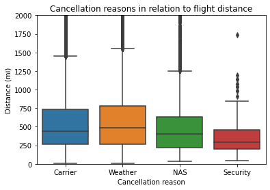

# Conclusion

- **Delays were only briefly touched upon** and would need to be explored more in-depth.  
  Possibly other factors have more influence here: specific carriers, airports, maybe even specific planes or their characteristics?
- Do you really need to worry about cancelled flights?  
  In normal times, around **2%** of US flights got **cancelled or diverted**.  
  Not much if you ask me or compare it to the risk of being stuck in a traffic jam.
- If you feel like being a bit **more on a safe side**, pick **May or November Saturdays**!